# Assignment 2 - Part B

Done by :

- P1935727 Ng Zhan Kang
- P1935488 Triston Loh

Class of DIT/FT/2B/11

# 1.Ensuring GPU Utilization is minimal

### 1.1 Ensuring 0% Util

Ensure that our slot give by Google is not utilized yet.

```python
# to ensure that the current gpu utilization is 0
# memory footprint support libraries/code
!ln -sf /opt/bin/nvidia-smi /usr/bin/nvidia-smi
!pip install gputil
!pip install psutil
!pip install humanize
import psutil
import humanize

import os
import GPUtil as GPU
GPUs = GPU.getGPUs()
# XXX: only one GPU on Colab and isn’t guaranteed
gpu = GPUs[0]
def printm():
 process = psutil.Process(os.getpid())
 print("Gen RAM Free: " + humanize.naturalsize( psutil.virtual_memory().available ), " | Proc size: " + humanize.naturalsize( process.memory_info().rss))
 print("GPU RAM Free: {0:.0f}MB | Used: {1:.0f}MB | Util {2:3.0f}% | Total {3:.0f}MB".format(gpu.memoryFree, gpu.memoryUsed, gpu.memoryUtil*100, gpu.memoryTotal))
printm()
```

```
Gen RAM Free: 26.3 GB  | Proc size: 112.8 MB
GPU RAM Free: 16160MB | Used: 0MB | Util   0% | Total 16160MB
```

## 1.2. Forcing Utils To 0% To Get A Clean Cluster

Please do not use this step unless the cluster you are allocated to is quite full.

```python
## if utilization is > 0, run this code(keep running this cell and the above cell till the util number is 0%):
## NOTE THAT RUNNING THIS MIGHT KILL GPU SESSION AND RESULT IN DATA LOSS(NOT ADVICABLE TO KEEP ON REUSING)
# !kill -9 -1
```

# 2.Ensuring GPU Is Utilized In Environment

### 2.1. See the list of available devices

This entire section can be omitted if users are not utilizing GPU at all.

```python
from tensorflow.python.client import device_lib
print(device_lib.list_local_devices())
```

```
[name: "/device:CPU:0"
device_type: "CPU"
memory_limit: 268435456
locality {
}
incarnation: 9788418784772983066
, name: "/device:GPU:0"
device_type: "GPU"
memory_limit: 15507165056
locality {
  bus_id: 1
  links {
  }
}
incarnation: 15164680118010082676
physical_device_desc: "device: 0, name: Tesla V100-SXM2-16GB, pci bus id: 0000:00:04.0, compute capability: 7.0"
]
```

```python
!nvidia-smi
```

```
Thu Feb 18 22:20:09 2021
+-----------------------------------------------------------------------------+
| NVIDIA-SMI 460.32.03    Driver Version: 460.32.03    CUDA Version: 11.2     |
|-------------------------------+----------------------+----------------------+
| GPU  Name        Persistence-M| Bus-Id        Disp.A | Volatile Uncorr. ECC |
| Fan  Temp  Perf  Pwr:Usage/Cap|         Memory-Usage | GPU-Util  Compute M. |
|                               |                      |               MIG M. |
|===============================+======================+======================|
|   0  Tesla V100-SXM2...  Off  | 00000000:00:04.0 Off |                    0 |
| N/A   35C    P0    39W / 300W |    427MiB / 16160MiB |      5%      Default |
|                               |                      |                  N/A |
+-------------------------------+----------------------+----------------------+

+-----------------------------------------------------------------------------+
| Processes:                                                                  |
|  GPU   GI   CI        PID   Type   Process name                  GPU Memory |
|        ID   ID                                                   Usage      |
|=============================================================================|
+-----------------------------------------------------------------------------+
```

# 3.Installing OpenAI and necessary dependencies

### 3.1. Install X11 system, Python and other dependencies.

Now we are going to install X11 to render display in google colab and other dependencies to make sure we can run OpenAI environments in Google Colab.

```python
%%bash
# install required system dependencies
apt-get install -y xvfb x11-utils

# install required python dependencies
pip install pyvirtualdisplay==0.2.* \
            PyOpenGL==3.1.* \
            PyOpenGL-accelerate==3.1.*
```

```
Reading package lists...
Building dependency tree...
Reading state information...
x11-utils is already the newest version (7.7+3build1).
xvfb is already the newest version (2:1.19.6-1ubuntu4.8).
0 upgraded, 0 newly installed, 0 to remove and 10 not upgraded.
```

### 3.2. Check for running background running displays

We will check if there is any running background display first before we proceed on. Empty just means nothing running.

```python
!echo $DISPLAY
```

### 3.3. Create a virtual display in background

This code here will create a new virtual display in the background that the Gym Envs can connect for rendering. We will echo to check again if there is any running background displays, and this time there should be something.

```python
import pyvirtualdisplay
_display = pyvirtualdisplay.Display(visible=False,  # use False with Xvfb
                                    size=(1400, 900))
_ = _display.start()
```

```python
!echo $DISPLAY
```

```
:1001
```

# 4.Background Information

### 4.1. About Super Mario Bros OpenAI gym

### BACKGROUND

- - Super Mario Bros is a game developed by and released by Nintendo in Japan in the year 1985. **It is not a game listed in Atari games and furthermore, Gym doesn’t natively support games from the Nintendo Entertainemnt System (NES). Hence, we have to install the OpenAI gym environment on (NES) using the nes-py emulator.** The very first version of Super Mario Bros released officially by Pypi was in April 27, 2018. The author and maintainer of the Super Mario Bros OpenAI gym is **Christian Kauten**.

### GAMEPLAY

- - The original super mario bros, like what we all know, is to let users take on the role of Mario, and race through the mushroom kingdom, survive the main antagonist Browser's forces, and save Princess Toadstool. It is a side-scrolling platformer, so players can move from the left side to the right side in order to reach the flag pole at the end of every level.
  - The game also includes coins scattered around for Mario to collect and special bricks marked with question marks, which when hit from below by Mario may reveal more coins or a special item.

### GYM-SUPER-MARIO

- - We had a kind user who managed to create the super mario gym environment on the nes(Nintendo Entertainment System) using the nes-py emulator.
  - The agent interacts with the environment by choosing which action to take from a list of possible actions provided by the action space of the environment. There are 3 different possible action list to choose from, namely, **RIGHT_ONLY, SIMPLE_MOVEMENT AND COMPLEX_MOVEMENT**. In our project, we have selected the **COMPLEX_MOVEMENT** as we want the agent, Mario to learn as many types of actions as possible so that it can reach far into the level or even complete the level.
  - The goal of the game is for the agent, Mario, to race through the level to get to the flag pole at the end of the level. We are not targetting to get mario to get as many coins as possible or kill as many opponents as possible. We are however just trying to get mario to run as far to the right as possible, which ultimately is securing the flagpole. Mario must succeed by getting pass obstacles such as pipes and enemies such as the mushrooms. As per defined in [gym-super-mario](https://pypi.org/project/gym-super-mario-bros/), for individual stages, there is only **one** life given to mario to make it through the single stage of the game. So if mario were to die, the entire env will reset. Mario, like what we know, will die if it takes damage from the enemy mushroom or falls into the pit.
  - We do want to note **once again that in the entire project we are not training mario to get as many in-game incentives as possible, but however to go as far to the right as possible, which eventually means capturing the flag pole.**

### COMPARISON OF DIFFERENT RL ALGORITHMS

- - **Deep-Q Network (DQN):**
    - Based on Q-network
    - Requires a target network for stability
    - Requires Prioritized Experience Replay for efficient sampling
    - Off-policy method
    - Slow convergence, high efficiency
  - **Trust Region Policy Optimization (TRPO):**
    - On-policy algorithm
    - Updates policies by taking the largest step possible to improve performance while satisfying a constraint-based on KL divergence on how close the new and old policies are allowed to be
    - Used for environments with either discrete or continuous action spaces
  - **Proximal Policy Optimization (PPO):**
    - On-policy algorithm
    - Simple to implement
    - Two variants of PPO:  
      PPO-Penalty -> (penalized KL divergence)  
      PPO-Clip -> (clips the objective function)
  - **Twin Delayed DDPG (TD3):**
    - Off-policy algorithm
    - Can only be used for environments with continuous action spaces
    - Not that good when it comes to tuning things such as hyperparameters
    - learns two Q-functions instead of one and uses the smaller of the two Q-values to form the targets in the loss functions
    - Updates the policy and target networks less frequently than the Q-function
    - Adds noise to the target action, to exploit Q-function errors by smoothing out Q along with changes in action
  - **Asynchronous Advantage Actor-Critic (A3C):**
    - Off-policy method
    - Actor and critic trains and updates in an asynchronous manner
    - Provides faster multi-processing than A2C
    - Faster convergence rate due to multiple instances running concurrently
  - **Soft Actor-Critic (SAC):**
    - Off-policy algorithm
    - Optimizes a stochastic policy and joins stochastic policy optimization and DDPG-style approaches
    - Uses clipped double-Q trick
    - Uses entropy regularization to train the policy to maximize the trade-off between expected return and entropy (randomness in the policy)
    - Learns a policy and two Q-functions simultaneously
  - **Conclusion:**
    - PPO provides better convergence and performance rate than other techniques but is sensitive to changes
    - DQN alone is unstable and gives poor convergence, hence requires several add-ons
    - SAC is very efficient for energy based optimization techniques due to entropy factor regularization
    - TD3 and TRPO work well with continuous action spaces but have slow convergence rate
    - A3C is very useful when large computation power and concept of transfer learning on similar environments is available

### PROXIMAL POLICY OPTIMIZATION (PPO)

- - We have went to do some research of different Reinforcement Learning Algorihtms initially, including the introduced DQL(Deep Q Learning) in class, A2C(Advantage Actor Critic), A3C(Asynchronous Advantage Actor Critic), TD3(Twin Delayed DDPG), SAC(Soft Actor-Critic). But as we went on to do the research, we realise that there are different classes of RL algorithms, with some being model-free and some which are model-based RL. Since we are dealing with the super mario environment, it is not a environment suited for model-based RL, for our agent is supposed to learn by itself, and we should have a reward system to reward the agent if it does the correct movements.
  - We went on to look into Model-Free RL, which is further splited into Q-Learning algorithms and Policy Optimization algorithms.
  - We were particularly interested in PPO and decided to inplement it. Proximal Policy Optimization (PPO) is a policy gradient method for reinforcement learning. The motivation was to have an algorithm with the data efficiency and reliable performance of Trust Region Policy Optimization (TRPO), while using only first-order optimization such as the **Gradient Descent Method** which is easy, fast and simple in optimizing an objective function. Studies have been conducted to show that PPO outperforms other online policy gradient methods and strikes a favorable balance between sample complexity, simplicity and wall-time.

## GRAPHICAL IMAGE OF ARCHITECTURE

[figure not shown]

### 4.2. Super Mario Bros OpenAI gym

- For this problem, create a PPO-Clip model and train it in the gym-super-mario environment such that it can complete a single world.
- Prepare the necessary classes and functions and preprocessing the environment data.
- Identify insights gathered and make reasonings from them.
- Form some conclusions.

# 5.Load Gym environment

### 5.1. Installing required modules

For this project, Super Mario is not included in OpenAI Gym environment, so we will need to install nes_py and gym_super_mario_bros.

```python
# nes_py is an external emulator and openai gym interface
!pip install nes_py
!pip install gym_super_mario_bros
```

### 5.2. Load the necessary libraries

We will load the necessary libraries first for this RL process.

```python
# suppress future warnings
import warnings
warnings.filterwarnings('ignore')
```

```python
# check versions of libraries we are going to use
%tensorflow_version 2.x
import os
import tensorflow
import sklearn
import numpy as np
import pandas as pd
import seaborn as sns
import matplotlib
import platform
import gym

message="        Versions        "
print("*"*len(message))
print(message)
print("*"*len(message))
print("Tensorflow version={}".format(tensorflow.__version__))
print("Keras version={}".format(tensorflow.keras.__version__))
print("Sklearn version={}".format(sklearn.__version__))
print("Numpy version={}".format(np.__version__))
print("Pandas version={}".format(pd.__version__))
print("Seaborn version={}".format(sns.__version__))
print("Matplotlib version={}".format(matplotlib.__version__))
print("Gym version={}".format(gym.__version__))
print("Python version={}".format(platform.python_version()))
```

```
        Versions
Tensorflow version=2.4.1
Keras version=2.4.0
Sklearn version=0.22.2.post1
Numpy version=1.19.5
Pandas version=1.1.5
Seaborn version=0.11.1
Matplotlib version=3.2.2
Gym version=0.17.3
Python version=3.6.9
```

```python
# get the main libraries we might be touching on first
import tensorflow as tf
import pandas as pd
import matplotlib.pyplot as plt
import seaborn as sns
import numpy as np
import random
import time
import copy
import os

# import the gym environment and super mario bros environment to run our game in
import gym
import gym_super_mario_bros
from nes_py.wrappers import JoypadSpace
from gym_super_mario_bros.actions import COMPLEX_MOVEMENT

# other libraries that we might use also
import cv2
from collections import deque
from multiprocessing import Process, Pipe

# import keras libriries for our neural networks
from tensorflow.keras.models import Model
from tensorflow.keras.layers import Conv2D, Dense, Flatten, LeakyReLU

# For displaying image
from IPython import display
```

```python
# just in case sample_data is in our working directory, get rid of it to also save space lol
!rm -rf sample_data
```

**Analysis Summary:** We used COMPLEX_MOVEMENT for our super mario actions. Initially there are 3 options, RIGHT_ONLY, SIMPLE_MOVEMENT and COMPLEX_MOVEMENT. The reason why we chose COMPLEX_MOVEMENT is because we want super mario to try nearly all of his possible actions in the game in order to make the process as realistic as possible. However, this will mean that there will be increased time and complexity for the agent to train. Now we will load some gym environemnt parameters.

# 6.Data Preprocessing

Here, we will create a few different classes that aids in preparing the environment, namely:

- Resetting the env upon dying, giving a reward of -50
- Restting the env upon getting the flag(completing a level), giving a reward of +100
- Scale our reward by 0.05 factor for stability purpose
- Resizing the image and grayscaling the screen for faster purpose of our Neural Network.
- Stochastic skipping of frames, or it will take a real long time, and to add randomness to the env.
- Stacking of frames to make it look like there is movements, similar to Atari DeepMind implementation.
- Scale the pixels by 255 to get a range of 0-1 for the pixels.

### 6.1. Define `EpisodicLifeEnv` class

We will define the points to award if mario dies or finishes the level.

```python
# EpisodicLifeEnv class to define how many reward to award the agent when dead or upon completion of a level
class EpisodicLifeEnv(gym.Wrapper):
  """
  EpisodicLifeEnv class to define how many reward to award the agent when dead or upon completion of a level
  """
  def __init__(self, env):
    gym.Wrapper.__init__(self, env)
    # boolean function. True means it either died or completed a level
    self.was_real_done = True

  # here, we will define the situational reward we will award the agent depending on the scenario
  def step(self, action):
    obs, reward, done, info = self.env.step(action)
    # if the flag is retrieved(reached finishing line)
    if self.env.unwrapped._flag_get:
      reward += 100
      done = True
    # if mario died(jus died, lol)
    if self.env.unwrapped._is_dying:
      reward -= 50
      done = True
    self.was_real_done = done
    return obs, reward, done, info

  # here, we will define a reset function so that if all the given lives to mario is finished, we will reset. this way,
  # the learner just need to learn and need not care about what is happening behind-the-scenes
  def reset(self, **kwargs):
    if self.was_real_done:
      obs = self.env.reset(**kwargs)
    else:
      # no-op step (no operation) to advance from the current lost-life state
      obs, _, _, _ = self.env.step(0)
    return obs
```

### 6.2. Define `RewardScalar` class

We will define how we scale the reward so that we place emphasis on actions that is important in that current state, so that it will make better decisions later on.

**Analysis Summary:** Here, we have to scale down our reward as it place emphasis on the immediate action/reward which is the most important for that state, which also takes into account potential future rewards to make a good choice if the maximum reward now typically leads to negative rewards later.

```python
# RewardScalar class to define scale our reward by a factor of 0.05. We have to do this as it will drastically affect the performance of the entire model
class RewardScalar(gym.RewardWrapper):
  """
  RewardScalar class to define scale our reward by a factor of 0.05
  """
  def reward(self, reward):
    return reward * 0.05
```

### 6.3. Define `PreprocessFrame` class

This class is created to change the frame the greyscale, and that we will resize the entire frame to 96x96x1.

```python
# PreprocessFrame class to convert into greyscale and resize the entire env.
class PreprocessFrame(gym.ObservationWrapper):
  """
  PreprocessFrame class to change the frame the greyscale, and that we will resize the entire frame to 96x96x1.
  """
  def __init__(self, env):
    gym.ObservationWrapper.__init__(self, env)
    self.width = 96
    self.height = 96
    self.observation_space = gym.spaces.Box(low=0, high=255, shape=(self.height, self.width, 1), dtype=np.uint8)

  def observation(self, frame):
    # here, we will use the cv2 library to change it to grayscale
    frame = cv2.cvtColor(frame, cv2.COLOR_BGR2GRAY)

    # resize the frame now!
    frame = cv2.resize(frame, (self.width, self.height), interpolation=cv2.INTER_AREA)
    frame = frame[:, :, None]

    return frame
```

### 6.4. Define `StochasticFrameSkip` class

Capturing each and every frame is really time comsuming and computationally heavy. We want to avoid that, and as such we introduce Stochastic frame skipping. Frame skipping will determine how long the agent does the selected action until selecting a new action.

```python
# StochasticFrameSkip class to skip some frames. Not too much and not too little
class StochasticFrameSkip(gym.Wrapper):
  """
  StochasticFrameSkip class to skip some frames.
  """
  def __init__(self, env, n, stickprob):
    gym.Wrapper.__init__(self, env)
    self.n = n
    self.stickprob = stickprob
    self.curac = None
    self.rng = np.random.RandomState()
    # check if it has the necessary attributes
    self.supports_want_render = hasattr(env, "supports_want_render")

  # reset function to reset the env upon the stochasticframeskipping
  def reset(self, **kwargs):
    self.curac = None
    return self.env.reset(**kwargs)

  # define how each step should be like
  def step(self, ac):
    done = False
    totrew = 0
    for i in range(self.n):
      # upon the 1st reset, use the action
      if self.curac is None:
        self.curac = ac
      # 1st substep, delay it with probability=stickprob
      elif i == 0:
        if self.rng.rand() > self.stickprob:
          self.curac = ac
      # 2nd substep, new action to kick in
      elif i == 1:
        self.curac = ac
      if self.supports_want_render and i < self.n-1:
        ob, rew, done, info = self.env.step(self.curac, want_render=False)
      else:
        ob, rew, done, info = self.env.step(self.curac)
      totrew += rew
      if done: break
    return ob, totrew, done, info

  # we need to set some randomness here
  def seed(self, s):
    self.rng.seed(s)
```

### 6.5. Define `ScaledFloatFrame` class

The `ScaledFloatFrame` class is where we will scale our frames by 255 to make it pixels of 0 and 1.

```python
# ScaledFloatFrame class to change our observations such that pixel values range between 0 and 1
class ScaledFloatFrame(gym.ObservationWrapper):
  """
  StochasticFrameSkip class to change our observations such that pixel values range between 0 and 1
  """
  def __init__(self, env):
    gym.ObservationWrapper.__init__(self, env)
    self.observation_space = gym.spaces.Box(low=0, high=1, shape=env.observation_space.shape, dtype=np.float32)

  def observation(self, observation):
    return np.array(observation).astype(np.float32) / 255.0
```

### 6.6. Define `FrameStack` class

The `FrameStack` class is similar to Atari's `baseline.common.atari_wrappers.LazyFrames`. What we will be doing here is to stack k last frames and return a lazy array, to make the entire thing more memory efficient.

The purpose of using LazyFrames is to save memory. As compared to its numpy array counterpart, the idea is to take the advantage of the fact that a numpy array can be saved at different lists at the same time as lists only save a reference not object itself.

```python
# FrameStack class to stack k last frames
class FrameStack(gym.Wrapper):
  """
  FrameStack class to stack k last frames
  """
  def __init__(self, env, k):
    gym.Wrapper.__init__(self, env)
    self.k = k
    self.frames = deque([], maxlen=k)
    shp = env.observation_space.shape
    self.observation_space = gym.spaces.Box(low=0, high=255, shape=(shp[:-1] + (shp[-1] * k,)), dtype=env.observation_space.dtype)

  # reset the environment
  def reset(self):
    ob = self.env.reset()
    for _ in range(self.k):
      self.frames.append(ob)
    return self._get_ob()

  # define how each step should trigger what actions
  def step(self, action):
    ob, reward, done, info = self.env.step(action)
    self.frames.append(ob)
    return self._get_ob(), reward, done, info

  # get the LazyFrames(OpenAI's method of array)
  def _get_ob(self):
    # check if the length is the same as k
    assert len(self.frames) == self.k
    return LazyFrames(list(self.frames))
```

### 6.7. Define `LazyFrame` class

The `LazyFrame` class is like a numpy array, just that it saves alot of memory as compared to its counterpart. As mentioned above, `LazyFrame` helps to save memory by taking advantage of the fact that a numpy array can be saved at different lists at the same time as lists only save a reference not object itself.

```python
# LazyFrames class to convert to numpy array before passing on the object to the model.
class LazyFrames(object):
  """
  This object ensures that common frames between the observations are only stored once.
  It exists purely to optimize memory usage which can be huge for DQN's 1M frames replay
  buffers.
  This object should only be converted to numpy array before being passed to the model.
  """
  def __init__(self, frames):
    self._frames = frames
    self._out = None

  # create a private force function to get values between 0 to 4th_index - 1
  def _force(self):
    if self._out is None:
      self._out = np.concatenate(self._frames, axis=-1)
      self._frames = None
    return self._out

  # overwrite the array python dict to make it work how we want array to work like
  def __array__(self, dtype=None):
    out = self._force()
    if dtype is not None:
      out = out.astype(dtype)
    return out

  # overwrite the len python dict to make it work how we want len to work like
  def __len__(self):
    return len(self._force())

  # define how we want to get the item
  def __getitem__(self, i):
    return self._force()[i]

  def count(self):
    frames = self._force()
    return frames.shape[frames.ndim - 1]

  def frame(self, i):
    return self._force()[..., i]
```

# 7.Make Environment

### 7.1. Initalize Working Environment

Here, we will create our super mario environment for our agents to run on. We will call the classes we created above.

**Analysis Summary:** Note that we will only do the entire training in 1 stage. Training the algorithm to complete all stages in the world will take a long time, which we do not have for this assessment.

```python
# we will create a make_env function here so that we can call it in our main function when we want to train the model
def make_env():
  env = gym_super_mario_bros.make('SuperMarioBros-1-1-v0') # we will set it to play in v0 of super mario bros, world 1 of stage 1. more can be found on the docs
  env = JoypadSpace(env, COMPLEX_MOVEMENT) # we will make it to complex movement
  env = EpisodicLifeEnv(env)
  env = RewardScalar(env)
  env = PreprocessFrame(env)
  env = StochasticFrameSkip(env, 4, 0.5)
  env = ScaledFloatFrame(env)
  env = FrameStack(env, 4)

  return env
```

### 7.2. Declare constants and variables

In here, we are going to declare what values we will use to train our models.

**Analysis Summary:** For users who have previous tensorflow event log data, please note to change start_t to the last t_step recorded, or it will not be rendered properly in TensorBoard.

```python
|env = make_env()
observation_shape = env.observation_space.shape
num_actions = env.action_space.n
num_actors = 4
gae_lambda = 0.95
gamma = 0.99
base_clip_epsilon = 0.2
max_steps = 1e7
base_learning_rate = 2.5e-5
horizon = 1280
batch_size = 320
optim_epochs = 5
value_loss_coefficient = .01
entropy_loss_coefficient = .01
gradient_max = 10.0
start_t = 0

SMALL_NUM = 1e-8

log_dir = "./log"
save_path = "./saved_models"

env_name = 'Dummy_Name_To_Update_To_Levels'
```

### 7.3. Checking out number of actions

Here, we can check out what are the sets of the actions for `COMPLEX_MOVEMENTS`.

```python
# take a look at the various possible actions
action_space = env.get_action_meanings()
action_space
```

```
['NOOP',
 'right',
 'right A',
 'right B',
 'right A B',
 'A',
 'left',
 'left A',
 'left B',
 'left A B',
 'down',
 'up']
```

### 7.4. Checking out pixel values per observations

Here, we can check out the pixel values per observations, how the pixels range from.

```python
# take a look at the lowest and highest values for each observation variable
low_observation = env.observation_space.low[0][0]
high_observation = env.observation_space.high[0][0]
low_observation, high_observation
```

```
(array([0., 0., 0., 0.], dtype=float32),
 array([255., 255., 255., 255.], dtype=float32))
```

**Analysis Summary:** We can see that for COMPLEX_MOVEMENTS, there are a total of 12 movements. We also can see that the min_value for pixel value of an observations is 0 and the max is 255px.

### 7.5. Checking out an observation frame

Here, we can check out an example of an observation frame in the super mario environment.

[figure not shown]

```python
# take a look at an example of how the game will render
render = lambda : plt.imshow(env.render(mode='rgb_array'))
render()
```

# 8.Create Mutiple Environments

### 8.1. Create a callable with multiple processes

Here, we will create a callable with multiple processes to create several actors, and also calculate the advantage estimators defined in the PPO documentation.

```python
# create a SubProcessEnv class so that we create differernt actors using multiple Processes and also to calculate the advantage estimators
class SubProcessEnv(object):
  def env_process(name, conn):
    while True:
      (cmd, args, kwargs) = conn.recv()
      if cmd == "reset":
        conn.send(env.reset())
      elif cmd == "step":
        conn.send(env.step(*args, **kwargs))
      elif cmd == "exit":
        break
      else:
        raise Exception("Unknow command %s" % (str(cmd),))

  def __init__(self, name, env):
    parent_conn, child_conn = Pipe()
    self.process = Process(target=SubProcessEnv.env_process, args=(name, child_conn))
    self.process.start()
    self.conn = parent_conn

  def step(self, action):
    self.conn.send(("step", (action,), {}))
    return self.conn.recv()

  def reset(self):
    self.conn.send(("reset", (), {}))
    return self.conn.recv()

  def exit(self):
    self.conn.send(("exit", (), {}))
    self.process.join()
```

```python
class TimeIndexedList(object):
  def __init__(self, first_t=0):
    self.first_t = first_t
    self.list = []

  # for flushing so that we do not keep history forever
  def flush_through(self, t):
    to_remove = t - self.first_t + 1
    if to_remove > 0:
      self.list = self.list[to_remove:]
      self.first_t = t + 1

  def append(self, elem):
    self.list.append(elem)

  def get(self, t):
    return self.list[t - self.first_t]

  def future_length(self):
    return len(self.list)

  def get_range(self, t, length):
    return self.list[(t - self.first_t):(t - self.first_t + length)]
```

### 8.2. Define `EnvActor`

We will create a `EnvActor` class to define how we collect sample data from the running environment upon a single environment execution.

**Analysis Summary:** This is where we will define what data an actor will contain.

```python
# data relevant to executing and collecting samples from a single environment execution.
class EnvActor(object):
  def __init__(self, env):
    self.env = env
    self.obs = TimeIndexedList(first_t = start_t)
    self.last_obs = self.env.reset()
    self.last_obs = np.expand_dims(self.last_obs , axis = 0)
    self.last_obs = tf.convert_to_tensor(self.last_obs, dtype=tf.float32)     # for performance
    self.obs.append(self.last_obs)
    self.act = TimeIndexedList(first_t = start_t)
    self.rew = TimeIndexedList(first_t = start_t)
    self.val = TimeIndexedList(first_t = start_t)
    self.policy = TimeIndexedList(first_t = start_t)
    self.delta = TimeIndexedList(first_t = start_t)
    self.done = TimeIndexedList(first_t = start_t)
    self.episode_start_t = 0
    self.episode_rewards = []
    self.episode_x = []
    self.rewards_this_episode = []
    self.x_this_episode = []
    self.advantage_estimates = TimeIndexedList(first_t = start_t)
    self.value_estimates = TimeIndexedList(first_t = start_t)

  def step_env(self,policy_net,value_net,t):
    if t == start_t:
      # artifact of ordering
      val_0 = value_net(self.last_obs).numpy()[0]
      self.val.append(val_0[0])

    policy_t = policy_net(self.last_obs).numpy()[0]
    action_t = np.random.choice(num_actions, 1, p=policy_t)[0]

    obs_tp1,rew_t,done_t,info_t = self.env.step(action_t)
    obs_tp1 = np.expand_dims(obs_tp1,axis = 0)

    self.act.append(action_t)
    self.rew.append(rew_t)
    self.policy.append(policy_t)
    self.rewards_this_episode.append(rew_t)
    self.x_this_episode.append(info_t.get('x_pos'))

    if done_t:
      self.done.append(True)
      self.episode_rewards.append(sum(self.rewards_this_episode))
      self.rewards_this_episode = []
      self.episode_x.append(self.x_this_episode)
      self.x_this_episode = []
      obs_tp1 = self.env.reset()
      obs_tp1 = np.expand_dims(obs_tp1,axis = 0)
      self.episode_start_t = t + 1
    else:
      self.done.append(False)

    # Important to put this after we've updated obs_tp1 in case of reset.
    # NOTE: Bug fix, obs_horizon was being added to before the possible reset, so wrong observation was associated to initial policy step.
    self.obs.append(obs_tp1)

    obs_tp1 = tf.convert_to_tensor(obs_tp1, dtype=tf.float32)     # for performance
    val_tp1 = value_net(obs_tp1).numpy()[0]
    self.val.append(val_tp1[0])
    self.delta.append(self.rew.get(t) + (1 - indicator(done_t)) * gamma * self.val.get(t + 1) - self.val.get(t))
    self.last_obs = obs_tp1

  # end_t is non-inclusive, i.e. it's the t immediately after the desired horizon.
  def calculate_horizon_advantages(self, end_t):
      advantage_estimates = []
      value_estimates = []
      advantage_so_far = 0
      # No empirical estimate beyond end of horizon, so use value function.  Is immediately reset to 0 if at episode boundary.
      last_value_sample = self.val.get(end_t)
      for ii in range(horizon):
          if self.done.get(end_t - ii - 1):
              advantage_so_far = 0
              last_value_sample = 0

          # Insert in reverse order.
          advantage_so_far = self.delta.get(end_t - ii - 1) + (gamma * gae_lambda * advantage_so_far)
          advantage_estimates.append(advantage_so_far)
          # NOTE: using 1-step value update here; instead use the GAE value estimate (i.e. Q(s,a) with the empirical action.)
          # last_value_sample = (1 - indicator(self.done.get(end_t - ii - 1))) * gamma * last_value_sample + self.rew.get(end_t - ii - 1)
          # Didn't need the 1 - indicator since setting this above.
          last_value_sample = gamma * last_value_sample + self.rew.get(end_t - ii - 1)
          value_estimates.append(last_value_sample)

      advantage_estimates.reverse()
      value_estimates.reverse()

      # NOTE: Was normalizing here, but moved that to whole batch.
      for ii in range(len(advantage_estimates)):
          self.advantage_estimates.append(advantage_estimates[ii])
          self.value_estimates.append(value_estimates[ii])

  def get_horizon(self, end_t):
      return (self.obs.get_range(end_t - horizon, horizon),
              self.act.get_range(end_t - horizon, horizon),
              self.policy.get_range(end_t - horizon, horizon),
              self.advantage_estimates.get_range(end_t - horizon, horizon),
              self.value_estimates.get_range(end_t - horizon, horizon))

  def flush(self, end_t):
      # retain some extra observations for preprocessing step.
      self.obs.flush_through(end_t - horizon - 5)
      self.act.flush_through(end_t - horizon - 1)
      self.rew.flush_through(end_t - horizon - 1)
      self.val.flush_through(end_t - horizon - 1)
      self.policy.flush_through(end_t - horizon - 1)
      self.delta.flush_through(end_t - horizon - 1)
      self.done.flush_through(end_t - horizon - 1)
```

# 9.Create Auxiliars for workflow

### 9.1. Convert pixel values to tensor-like forms

We will define how we manage to convert the pixel values into tensor-like forms.

```python
def alpha_anneal(t):
  return tf.convert_to_tensor(np.maximum(1.0 - (float(t) / float(max_steps)), 0.0), dtype=tf.float32)

# convert into 0 and 1
def indicator(x):
  if x:
    return 1
  else:
    return 0
```

### 9.2. Define how to save models

We will now define how we save the models, both the `value_net` and the `policy_net`.

```python
def saver(nets, path):
  if not os.path.exists(path):
    os.makedirs(path)

  for i in range(len(nets)):
    if i == 0:
      name = 'value_net'
    if i == 1:
      name = 'policy_net'
    nets[i].save_weights(os.path.join(path, ("model_" + name)))
```

### 9.3. Define how to load models

We will now define how we load the models, both the `value_net` and the `policy_net`.

```python
def loader(nets, path):
  assert os.path.exists(path) == True
  assert len(nets) == 2

  for i in range(len(nets)):
    if i == 0:
      name = 'value_net'
    if i == 1:
      name = 'policy_net'
    nets[i].load_weights(os.path.join(path, ("model_" + name)))
    print('Load model ' + name)

def sum_writer(Writer, var, step , name):
  with Writer.as_default():
    tf.summary.scalar(name, var, step=step)
    Writer.flush()

def loader_test(nets, path):
  assert os.path.exists(path) == True

  name = 'policy_net'
  nets.load_weights(os.path.join(path, ("model_" + name)))
  print('Load model ' + name)
```

# 10.Define Neural Network

**Analysis Summary:** In Proximal Policy Optimization, there are 2 things called the value network and the policy network. The policy network does things by learning to give a definite output by giving a particular input to the game. The value network assigns value/score to the state of the game by calculating an expected cumulative score for the current state s . Every state goes through the value network. The states which gets more reward obviously get more value in the network.

### 10.1. Create value neural network for PPO

This is where we will define our neural network for our PPO value network. We will not make it too complicated for it will zap a lot of computational power. Instead of using the Keras `Sequential` API, we wil build from scratch using the Keras `Model` class.

```python
class value_nn(Model):
  def __init__(self):
    super(value_nn, self).__init__(name="Value_Net")

    self.conv1 = Conv2D(filters=32, kernel_size=(8, 8), strides=(4, 4), padding='same',
                        input_shape=observation_shape,
                        kernel_initializer=tf.keras.initializers.Orthogonal(np.sqrt(2)),
                        bias_initializer=tf.keras.initializers.Zeros(),
                        activation='linear')

    self.conv2 = Conv2D(filters=64, kernel_size=(4, 4), strides=(2, 2), padding='same',
                        kernel_initializer=tf.keras.initializers.Orthogonal(np.sqrt(2)),
                        bias_initializer=tf.keras.initializers.Zeros(),
                        activation='linear')

    self.conv3 =  Conv2D(filters=64, kernel_size=(3, 3), strides=(1, 1), padding='same',
                         kernel_initializer=tf.keras.initializers.Orthogonal(np.sqrt(2)),
                         bias_initializer=tf.keras.initializers.Zeros(),
                         activation='linear')

    self.flatten = Flatten()

    self.dense1 = Dense(512, kernel_initializer=tf.keras.initializers.Orthogonal(np.sqrt(2)),
                        bias_initializer=tf.keras.initializers.Zeros(),
                        activation='relu')

    self.out = Dense(1, activation='linear', bias_initializer=tf.keras.initializers.Ones(),
                     kernel_initializer=tf.keras.initializers.Orthogonal(.01))

  @tf.function
  def call(self, inputs):
    x = self.conv1(inputs)
    x = LeakyReLU()(x)
    x = self.conv2(x)
    x = LeakyReLU()(x)
    x = self.conv3(x)
    x = LeakyReLU()(x)
    x = self.flatten(x)
    x = self.dense1(x)
    return self.out(x)
```

### 10.2. Defining Policy Neural Network for PPO

This is where we will define our neural network for our PPO policy network. We will not make it too complicated for it will zap a lot of computational power. Instead of using the Keras `Sequential` API, we wil build from scratch using the Keras `Model` class.

```python
class policy_nn(Model):
  def __init__(self):
    super(policy_nn, self).__init__(name='Policy_Net')

    self.conv1 = Conv2D(filters=32, kernel_size=(8, 8), strides=(4, 4), padding='same',
                        input_shape=observation_shape, kernel_initializer=tf.keras.initializers.Orthogonal(np.sqrt(2)),
                        bias_initializer=tf.keras.initializers.Zeros(),
                        activation='linear')

    self.conv2 = Conv2D(filters=64, kernel_size=(4, 4), strides=(2, 2), padding='same',
                        kernel_initializer=tf.keras.initializers.Orthogonal(np.sqrt(2)),
                        bias_initializer=tf.keras.initializers.Zeros(),
                        activation='linear')

    self.conv3 = Conv2D(filters=64, kernel_size=(3, 3), strides=(1, 1), padding='same',
                        kernel_initializer=tf.keras.initializers.Orthogonal(np.sqrt(2)),
                        bias_initializer=tf.keras.initializers.Zeros(),
                        activation='linear')

    self.flatten = Flatten()

    self.dense1 = Dense(512, kernel_initializer=tf.keras.initializers.Orthogonal(np.sqrt(2)),
                        bias_initializer=tf.keras.initializers.Zeros(),
                        activation='relu')

    self.out = Dense(num_actions, bias_initializer=tf.keras.initializers.Zeros(),
                     activation='softmax')

  @tf.function
  def call(self, inputs):
    x = self.conv1(inputs)
    x = LeakyReLU()(x)
    x = self.conv2(x)
    x = LeakyReLU()(x)
    x = self.conv3(x)
    x = LeakyReLU()(x)
    x = self.flatten(x)
    x = self.dense1(x)
    return self.out(x)
```

# 11.PPO

### 11.1. Define PPO loss and gradients

We will define the PPO loss and their gradients.

**Analysis Summary:** Bear in mind that there are 2 versions of PPO, and the PPO version we are using here is the PPO-Clip variant, which does not have a KL-divergence(Kullback–Leibler) term and it doesn not have constraint at all. It relies on specialized clipping in the objective function to remove incentives for the new policy to get far from the old policy.

```python
@tf.function(experimental_relax_shapes=True)
def ppo_loss(alpha, policy_network, value_network, observation, actions, advantages, old_policies, old_values):
  policies = policy_network(observation)
  values = value_network(observation)
  values = tf.squeeze(values, axis=1)
  act_onehot = tf.one_hot(actions, num_actions)
  clip_epsilon = tf.math.multiply(alpha, base_clip_epsilon)
  log_prob_ratio = tf.math.log(tf.reduce_sum(policies * act_onehot, axis=1)) - tf.math.log(tf.reduce_sum(old_policies * act_onehot, axis=1))
  prob_ratio = tf.math.exp(log_prob_ratio)
  clipped_prob_ratio = tf.clip_by_value(prob_ratio, 1 - clip_epsilon, 1 + clip_epsilon)
  entropy_loss = -tf.reduce_sum(- policies * tf.math.log(policies), axis=1)
  clip_loss = -tf.math.minimum(prob_ratio * advantages, clipped_prob_ratio * advantages)
  value_loss = tf.math.square(values - old_values)
  total_loss = tf.reduce_mean(clip_loss + value_loss_coefficient * value_loss + entropy_loss_coefficient * entropy_loss)
  return entropy_loss, clip_loss, value_loss, total_loss
```

```python
def gradients(optimizer):
  @tf.function
  def apply_grads(alpha,policy_network,value_network,observation,actions,advantages,old_policies,old_values):
    with tf.GradientTape() as tape:
      entropy_loss, clip_loss, value_loss, total_loss = ppo_loss(alpha,policy_network,value_network,observation,actions,advantages,old_policies,old_values)
    variables = (policy_network.trainable_variables + value_network.trainable_variables)
    gradients = tape.gradient(total_loss, variables)
    clipped_gradients, _ = tf.clip_by_global_norm(gradients, gradient_max)
    optimizer.apply_gradients(zip(clipped_gradients, variables))
    return entropy_loss, clip_loss, value_loss, total_loss
  return apply_grads
```

# 12.Training

### 12.1. Download the model

If you wish to save the model when you want to call it a day, please download it here.

```python
# UNCOMMENT IF YOU WISH TO SAVE THE MODEL


# from google.colab import files
# !zip -r /content/log.zip /content/log
# !zip -r /content/saved_models.zip /content/saved_models

# files.download("/content/log.zip")
# files.download("/content/saved_models.zip")
```

[output not shown]

### 12.2. Load the model

If you wish to resume from the checkpoint where u saved, please upload it here. Please do not delete the events file from the folder as it will affect the history reading in tensorboard.

```python
# UNCOMMENT IF YOU WISH TO LOAD THE MODEL AFTER YOU UPLOAD THE ZIP FOLDERS TO THE CURRENT WORKING DIR


# from zipfile import ZipFile
# file_name = '/content/log.zip'
# file_name2 = '/content/saved_models.zip'

# with ZipFile(file_name, 'r') as zippy:
#   zippy.extractall('/')
#   print('Done Upzipping log folder!')

# with ZipFile(file_name2, 'r') as zippy:
#   zippy.extractall('/')
#   print('Done Upzipping saved_models folder!')
```

### 12.3. Load TensorBoard

We load TensorBoard here first so that later on we can go and see the lineplot of the average rewards earned,average X and max_x based on the number of steps.

```python
%load_ext tensorboard
%tensorboard --logdir log
```

```
The tensorboard extension is already loaded. To reload it, use:
  %reload_ext tensorboard
```

### 12.4. Train the model

We will now start training our model. Depending on how well you want it to be trained, you can let it run till you feel that it has hit a desired result.

```python
# standardize all to be float32 format
tf.keras.backend.set_floatx('float32')

# the train function saves the weights of the model every 1000 timesteps
# it will also create summary files to allow us to visualize the change of the average total reward, average x-position and max value of x-position
# the load of the weights will be True as default if you have previously saved the model. otherwise, set it as false
def train(load=True):
  writer_sum = tf.summary.create_file_writer(log_dir)
  t = start_t
  last_save = 0

  actors = []
  value_network = value_nn()
  policy_network = policy_nn()

  if load:
    loader([value_network, policy_network], save_path)

  for ii in range(num_actors):
    actors.append(EnvActor(SubProcessEnv(env_name, env)))

  while t <= max_steps:
    learning_rate = base_learning_rate * alpha_anneal(t)
    adam = tf.keras.optimizers.Adam(learning_rate=learning_rate, epsilon=1e-5)
    model_grads = gradients(adam)

    for ii in range(horizon):
      for actor in actors:
        actor.step_env(policy_network, value_network, t)
      t += 1

    for actor in actors:
      actor.calculate_horizon_advantages(t)

    # construct randomly sampled (without replacement) mini-batches
    obs_horizon = []
    act_horizon = []
    policy_horizon = []
    adv_est_horizon = []
    val_est_horizon = []

    for actor in actors:
      obs_a, act_a, policy_a, adv_est_a, val_est_a = actor.get_horizon(t)
      obs_horizon.extend(obs_a)
      act_horizon.extend(act_a)
      policy_horizon.extend(policy_a)
      adv_est_horizon.extend(adv_est_a)
      val_est_horizon.extend(val_est_a)

    # normalizing advantage estimates
    adv_est_horizon = np.array(adv_est_horizon)
    adv_est_horizon = (adv_est_horizon - np.mean(adv_est_horizon)) / (np.std(adv_est_horizon) + SMALL_NUM)

    num_samples = len(obs_horizon)
    indices = list(range(num_samples))

    for e in range(optim_epochs):
      random.shuffle(indices)
      ii = 0

      while ii < num_samples:
        obs_batch = []
        act_batch = []
        policy_batch = []
        adv_batch = []
        value_sample_batch = []

        for b in range(batch_size):
          index = indices[ii]
          obs_batch.append(np.squeeze(obs_horizon[index], axis=0))
          act_batch.append(act_horizon[index])
          policy_batch.append(policy_horizon[index])
          adv_batch.append(adv_est_horizon[index])
          value_sample_batch.append(val_est_horizon[index])
          ii += 1

        # training loop
        obs_batch = tf.convert_to_tensor(np.asarray(obs_batch), dtype=tf.float32)
        act_batch = tf.convert_to_tensor(np.asarray(act_batch), dtype=tf.uint8)
        policy_batch = tf.convert_to_tensor(np.asarray(policy_batch), dtype=tf.float32)
        adv_batch = tf.convert_to_tensor(np.asarray(adv_batch), dtype=tf.float32)
        value_sample_batch = tf.convert_to_tensor(np.asarray(value_sample_batch), dtype=tf.float32)

        # calling function of training
        entropy_loss, clip_loss, value_loss, total_loss = model_grads(alpha_anneal(t),
                                                                      policy_network, value_network, obs_batch, act_batch, adv_batch, policy_batch, value_sample_batch)

    for actor in actors:
      actor.flush(t)

    if t - last_save > 1000:
      saver([value_network, policy_network], save_path)
      last_save = t

    all_ep_rewards = []
    all_ep_x = []
    for actor in actors:
      all_ep_rewards.extend(actor.episode_rewards)
      all_ep_x.extend(actor.episode_x)
    if len(all_ep_rewards) >= 10:
      display.clear_output(wait=True)
      print("T: %d" % (t,))
      print("Avg Reward: %f" % (np.mean(all_ep_rewards),))
      print("Min Reward: %f" % (np.amin(all_ep_rewards),))
      print("Max Reward: %f" % (np.amax(all_ep_rewards),))
      print("Avg X: %f" % (np.hstack(all_ep_x).mean(),))
      print("Min X: %f" % (np.hstack(all_ep_x).min(),))
      print("Max X: %f" % (np.hstack(all_ep_x).max(),))
      print("----------------------")
      sum_writer(writer_sum, np.mean(all_ep_rewards), t, 'Avg_Reward')
      sum_writer(writer_sum, np.hstack(all_ep_x).mean(), t, 'Avg_X')
      sum_writer(writer_sum, np.hstack(all_ep_x).max(), t, 'Max_X')
      for actor in actors:
        actor.episode_rewards = []
        actor.episode_x = []

try:
  train()
except KeyboardInterrupt:
  pass
```

```
T: 775680
Avg Reward: 153.160000
Min Reward: 115.750000
Max Reward: 158.250000
Avg X: 1650.987703
Min X: 40.000000
Max X: 3161.000000
----------------------
```

[output not shown]

[output cut: 17 more lines]

[output not shown]

### 12.5. Test the model

We will now start testing our model.

```python
# the test function loads the weights of the model and test in the selected levels with the actions that are trained based on the level
# we will also create a video in mp4 format to show how our agent is able to get through the level
def test(episodes):

  env_test = make_env()
  policy_network = policy_nn()
  loader_test(policy_network, save_path)
  done=False
  scores=[]

  for e in range(episodes):
    state = env_test.reset()
    state = np.expand_dims(state, axis=0)
    state = tf.convert_to_tensor(state, dtype=tf.float32)
    score = 0
    video_frames = []
    while True:
      video_frames.append(cv2.cvtColor(env_test.render(mode='rgb_array'), cv2.COLOR_RGB2BGR))
      policy_t = policy_network(state).numpy()[0]
      action_t = np.argmax(policy_t)
      state, reward, done, _ = env_test.step(action_t)
      state = np.expand_dims(state, axis=0)
      state = tf.convert_to_tensor(state, dtype=tf.float32)
      score += reward

      if done:
        break

    video_name = 'test_' + str(e) + '.mp4'
    _, height, width, _ = np.shape(video_frames)
    fourcc = cv2.VideoWriter_fourcc(*'MP4V')
    video = cv2.VideoWriter(video_name, fourcc, 5, (width, height))
    for image in video_frames:
      video.write(image)

    cv2.destroyAllWindows()
    video.release()
    print('Test #%s , Score: %0.1f' %(e, score))
    scores.append(score)

  print('Average reward: %0.2f of %s episodes' %(np.mean(scores), episodes))
  return scores

scores = test(10)
```

```
Load model policy_net
Test #0 , Score: 120.4
Test #1 , Score: 158.3
Test #2 , Score: 120.4
Test #3 , Score: 120.4
Test #4 , Score: 116.0
Test #5 , Score: 158.2
Test #6 , Score: 158.0
Test #7 , Score: 158.3
Test #8 , Score: 158.3
Test #9 , Score: 120.4
Average reward: 138.90 of 10 episodes
```

# 13.Evaluation

### 13.1. Score plot

We will now plot out the scores of the test.

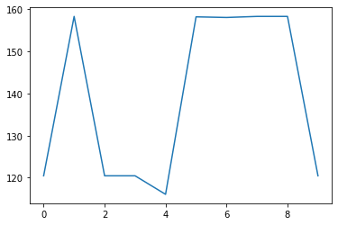

```python
# plot the scores
plt.plot(scores)
plt.show()
```

**Analysis Summary:** This is the scoreplot of the number of successes, which in this case is around the score of 158. We can see that we have around 5 test that managed to hit the score, out of the 10 test, and that most importantly our mario managed to capture the flag.

### 13.2. MP4 Video Output of Mario

Of course, we do have a chance to see how the algorithm learns how to operate mario!

```python
# go and load a successful mp4 video out
from IPython.display import HTML
from base64 import b64encode
import os

# Input video path
save_path = "/content/test_8.mp4"

# Compressed video path
compressed_path = "/content/test8_v2.mp4"

os.system(f"ffmpeg -i {save_path} -vcodec libx264 {compressed_path}")

# Show video
mp4 = open(compressed_path,'rb').read()
data_url = "data:video/mp4;base64," + b64encode(mp4).decode()
HTML("""
<video width=400 controls>
      <source src="%s" type="video/mp4">
</video>
""" % data_url)
```

[video not shown]

# 14.References

## Using Google Colab More Efficiently

1. [Getting the Most Out of Your Google Colab (Tutorial)](https://medium.com/@oribarel/getting-the-most-out-of-your-google-colab-2b0585f82403)
2. [Using Google Colab with GitHub](https://colab.research.google.com/github/googlecolab/colabtools/blob/master/notebooks/colab-github-demo.ipynb)
3. [Cloning Github repository to Colab Notebook](https://stackoverflow.com/a/57539179/12347869)

## Background Research

1. [Super Mario Bros. for OpenAI Gym](https://pypi.org/project/gym-super-mario-bros/#description)
2. [Super Mario Bros Wikipedia](https://en.wikipedia.org/wiki/Super_Mario_Bros.)
3. Which Reinforcement learning-RL algorithm to use where, when and in what scenario?
4. [Playing Super Mario Bros with Proximal Policy Optimization](https://brandinho.github.io/mario-ppo/)
5. RL — Proximal Policy Optimization (PPO) Explained
6. [Proximal Policy Optimization](https://paperswithcode.com/method/ppo)
7. Proximal Policy Optimization Algorithms.)
8. [OpenAI Original Proximal Policy Optimization](https://openai.com/blog/openai-baselines-ppo/)
9. [A Taxonomy of RL Algorithms](https://spinningup.openai.com/en/latest/spinningup/rl_intro2.html#a-taxonomy-of-rl-algorithms)
10. [PPO Background](https://spinningup.openai.com/en/latest/algorithms/ppo.html#background)

## Miscellaneous

1. [Tensorboard In Notebooks](https://colab.research.google.com/github/tensorflow/tensorboard/blob/master/docs/tensorboard_in_notebooks.ipynb#scrollTo=NiIMwOG8MR_g)
2. [How play mp4 video in google colab](https://stackoverflow.com/questions/57377185/how-play-mp4-video-in-google-colab)
3. [How do I download multiple files or an entire folder from Google Colab?](https://stackoverflow.com/questions/50453428/how-do-i-download-multiple-files-or-an-entire-folder-from-google-colab)

## External references

1. [Why reward scaling](https://www.reddit.com/r/learnmachinelearning/comments/arnpzs/why_are_rewards_scaled_when_using_reinforcement/)
2. [How does LazyFrames from OpenAI baselines save memory?](https://stackoverflow.com/questions/61151105/how-does-lazyframes-from-openais-baselines-save-memory#:~:text=The%20idea%20is%20to%20take,concatenated%20numpy%20array%20in%20self.)
3. [PPO by OpenAI](https://openai.com/blog/openai-baselines-ppo/)
4. [How to record video of agent's actions in a video file](https://stackoverflow.com/questions/52636899/python-openai-gym-monitor-creates-json-files-in-the-recording-directory)
5. [PPO Hyperparameters and Ranges](https://medium.com/aureliantactics/ppo-hyperparameters-and-ranges-6fc2d29bccbe)

## Blogs and samples reference

1. [Playing Super Mario Bros with Proximal Policy Optimization](https://brandinho.github.io/mario-ppo/)
2. [Super Mario Bros with PPO](https://github.com/brandinho/Super-Mario-Bros-PPO)
3. PPO-Mario-Bros-Tensorflow-2

## How to evaulate RL

1. [Evaluating Reinforcement Learning Algorithms](https://artint.info/2e/html/ArtInt2e.Ch12.S6.html)